# Open Street Map

Egypt, May-2021

Hany Nagaty

May-2021

# Open Street Maps Description

This is a brief description for the data downloaded from [Open Street Map](https://www.openstreetmap.org/#map=13/30.0225/31.4812) website. OSM is described as “a map of the world, created by people like you and free to use under an open license”. I downloaded the data for Egypt on May-2021. I used this [mirror](https://download.geofabrik.de/africa.html).

### The data has the below **16 layers**

## 1. `gis_osm_roads_free_1`

This is the **road network**. It has classes such as motorway, primary, secondary, residential, …..etc.

Total number of line segments: 1660855.

Counts Table

| Class | Count | Proportion |
| --- | --- | --- |
| residential | 1,155,867 | 69.59% |
| Other | 119,951 | 7.22% |
| footway | 114,721 | 6.91% |
| service | 103,036 | 6.20% |
| path | 98,261 | 5.92% |
| unclassified | 69,019 | 4.16% |

| bridge | n |
| --- | --- |
| F | 1,608,649 |
| T | 52,206 |

| tunnel | n |
| --- | --- |
| F | 1,660,021 |
| T | 834 |

| oneway | n |
| --- | --- |
| B | 1,575,859 |
| F | 84,989 |
| T | 7 |

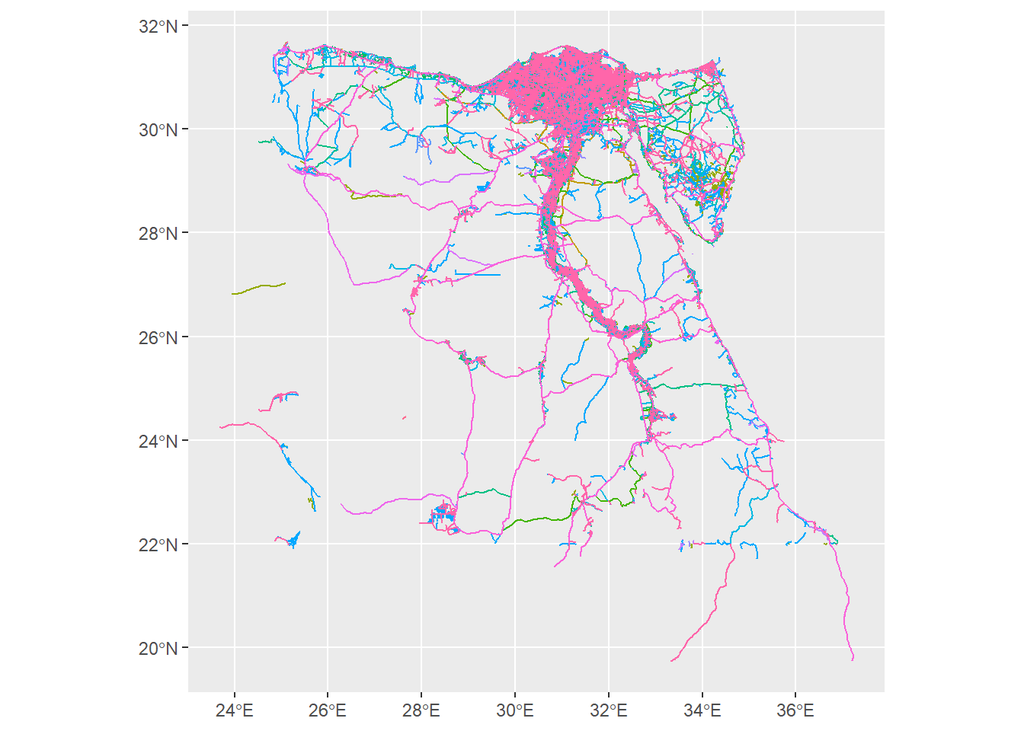

## 2. `gis_osm_pois_free_1`

**Points of Interest**. This might include shopping places, hotels, hospitals, water towers, telecom towers.  
*Note that the list is not comprehensive*

Total number of points: 12511

Counts Table

| Class | Count | Proportion |
| --- | --- | --- |
| Other | 8,468 | 67.68% |
| supermarket | 1,218 | 9.74% |
| restaurant | 1,103 | 8.82% |
| cafe | 666 | 5.32% |
| hotel | 543 | 4.34% |
| tower | 513 | 4.10% |

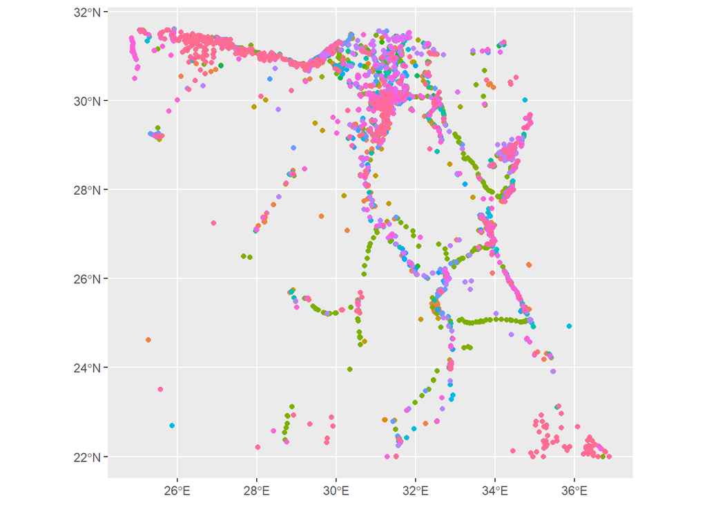

## 3. `gis_osm_pois_a_free_1`

Another set of **Points of Interest**.  
In contrast to the previous list, this list contains MULTIPOLYGON instead of POINT.

Total number of points: 10743

Counts Table

| Class | Count | Proportion |
| --- | --- | --- |
| Other | 3,833 | 35.68% |
| swimming_pool | 2,032 | 18.91% |
| pitch | 1,789 | 16.65% |
| park | 1,733 | 16.13% |
| ruins | 708 | 6.59% |
| hotel | 648 | 6.03% |

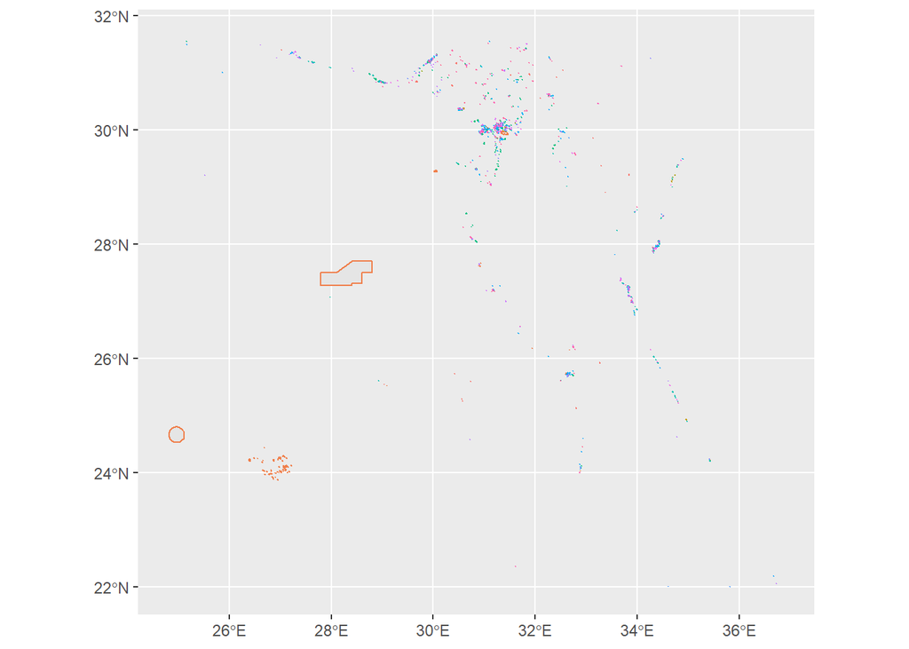

## 4. gis_osm_pofw_free_1

**Places of Worship**, this includes mosques and churches.

Total number of features: 732

Counts Table

| Class | Count | Proportion |
| --- | --- | --- |
| muslim | 488 | 66.67% |
| christian | 117 | 15.98% |
| muslim_sunni | 105 | 14.34% |
| christian_orthodox | 11 | 1.50% |
| christian_catholic | 7 | 0.96% |
| Other | 4 | 0.55% |

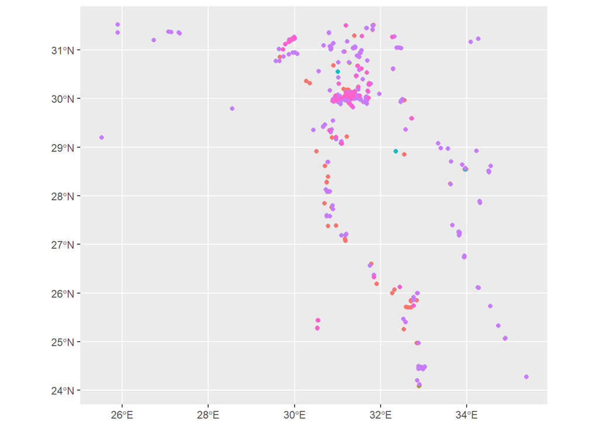

## 5. gis_osm_pofw_a_free_1

Another set of **Places of Worship**. The GIS features here are in POLYGON format rather than POINT format.

Total number of features: 953

Counts Table

| Class | Count | Proportion |
| --- | --- | --- |
| muslim | 575 | 60.34% |
| muslim_sunni | 268 | 28.12% |
| christian | 87 | 9.13% |
| christian_orthodox | 9 | 0.94% |
| jewish | 7 | 0.73% |
| Other | 7 | 0.73% |

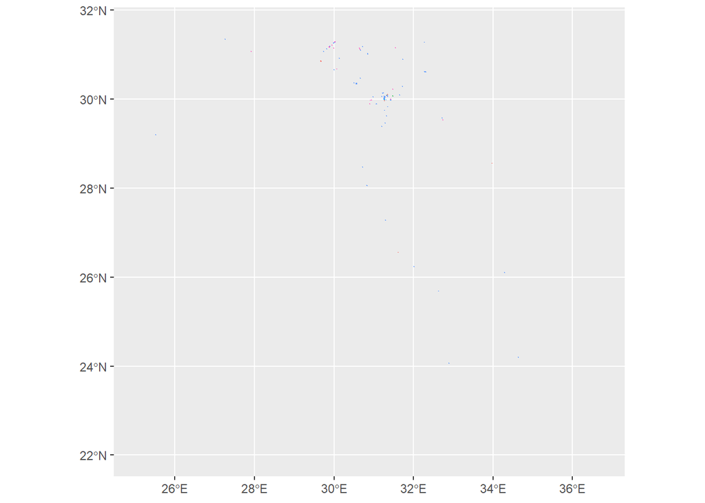

## 6. gis_osm_railways_free_1

This is the **railway network**. It has classes such as railway, tram and subway.

Total number of features: 1850

Counts Table

| Class | Count | Proportion |
| --- | --- | --- |
| rail | 1,626 | 87.89% |
| tram | 97 | 5.24% |
| narrow_gauge | 67 | 3.62% |
| subway | 50 | 2.70% |
| monorail | 5 | 0.27% |
| Other | 5 | 0.27% |

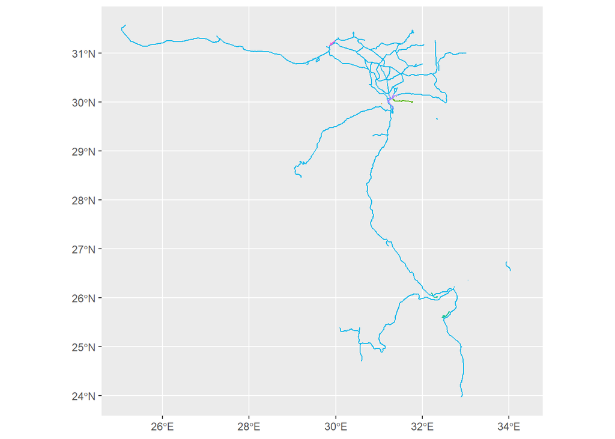

## 7. gis_osm_traffic_free_1

This is the **traffic landmarks**, such as crossings or junctions.

Total number of features: 7484

Counts Table

| Class | Count | Proportion |
| --- | --- | --- |
| crossing | 4,618 | 61.70% |
| motorway_junction | 1,351 | 18.05% |
| fuel | 473 | 6.32% |
| turning_circle | 371 | 4.96% |
| Other | 355 | 4.74% |
| parking | 316 | 4.22% |

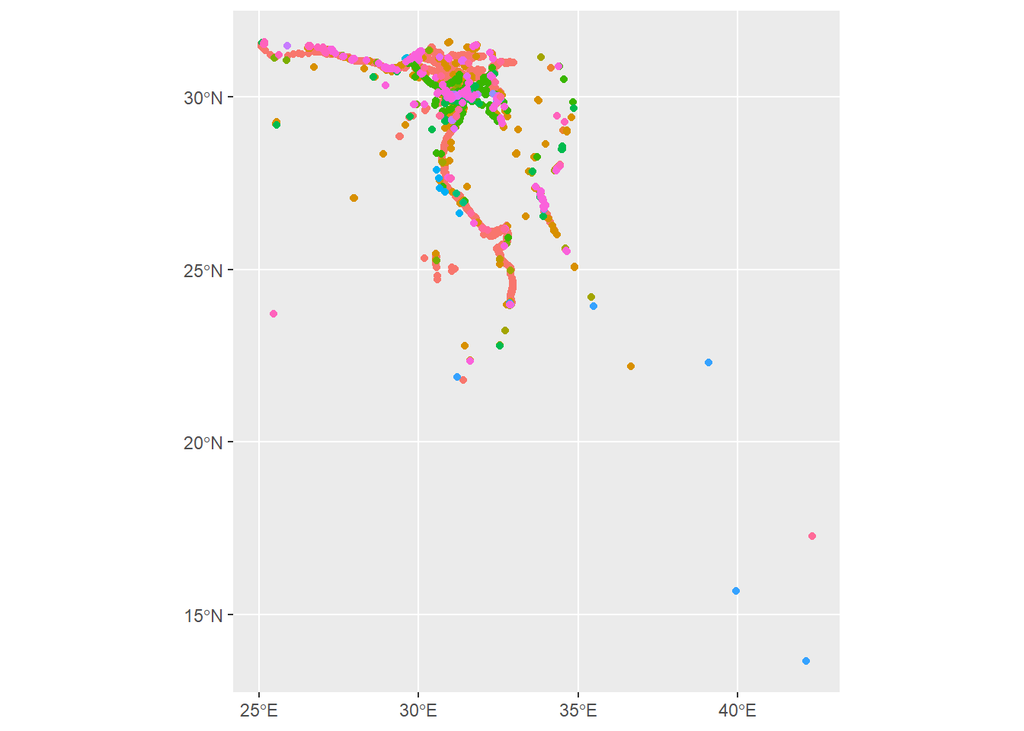

## 8. gis_osm_traffic_a_free_1

Another set of **traffic landmarks**. The GIS features here are in MULTIPOLYGON format rather than POINT format.

Total number of features: 2558

Counts Table

| Class | Count | Proportion |
| --- | --- | --- |
| parking | 1,327 | 51.88% |
| pier | 1,072 | 41.91% |
| fuel | 83 | 3.24% |
| Other | 35 | 1.37% |
| dam | 27 | 1.06% |
| service | 14 | 0.55% |

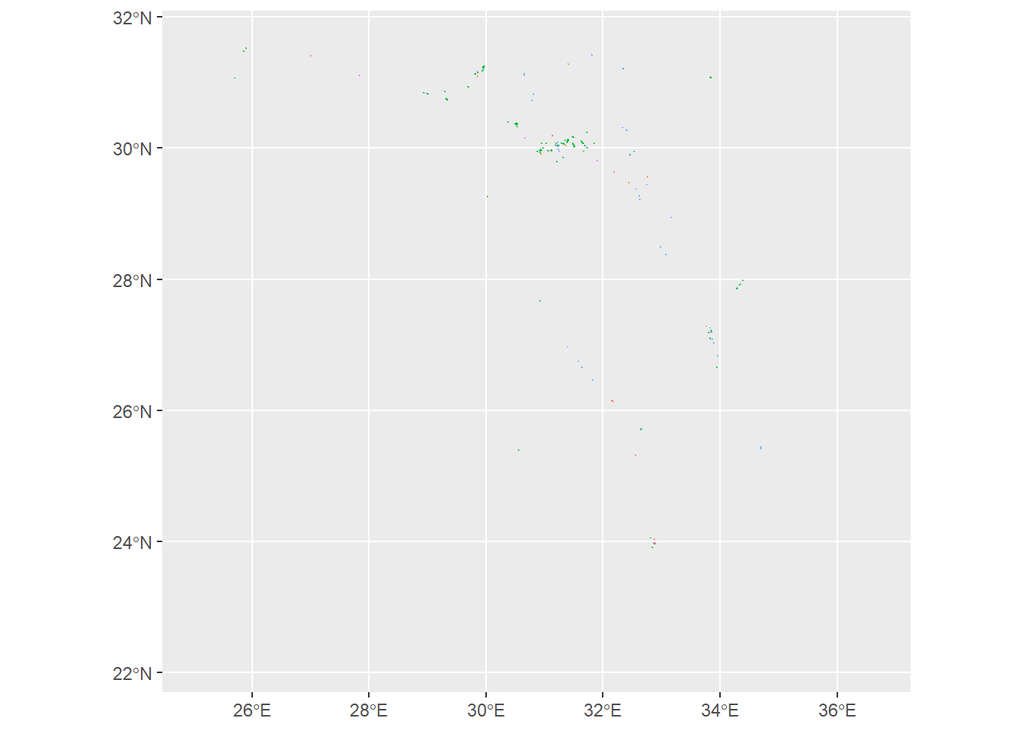

## 9. gis_osm_transport_free_1

**Transportation landmarks**, this includes bus stations and others.  
*The list is not comprehensive*

Total number of features: 1086

Counts Table

| Class | Count | Proportion |
| --- | --- | --- |
| railway_station | 341 | 31.40% |
| helipad | 174 | 16.02% |
| bus_station | 151 | 13.90% |
| Other | 149 | 13.72% |
| bus_stop | 141 | 12.98% |
| ferry_terminal | 130 | 11.97% |

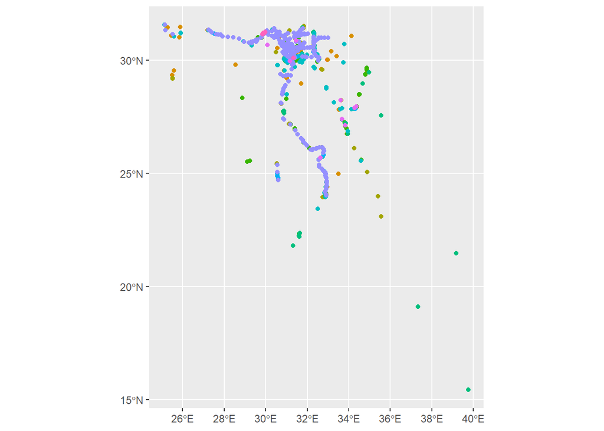

## 10. gis_osm_transport_a_free_1

Another set of **transportation landmarks**. The GIS features here are in MULTIPOLYGON format rather than POINT format.  
*The list is not comprehensive*

Total number of features: 515

Counts Table

| Class | Count | Proportion |
| --- | --- | --- |
| apron | 232 | 45.05% |
| helipad | 142 | 27.57% |
| bus_station | 63 | 12.23% |
| airport | 49 | 9.51% |
| railway_station | 16 | 3.11% |
| Other | 13 | 2.52% |

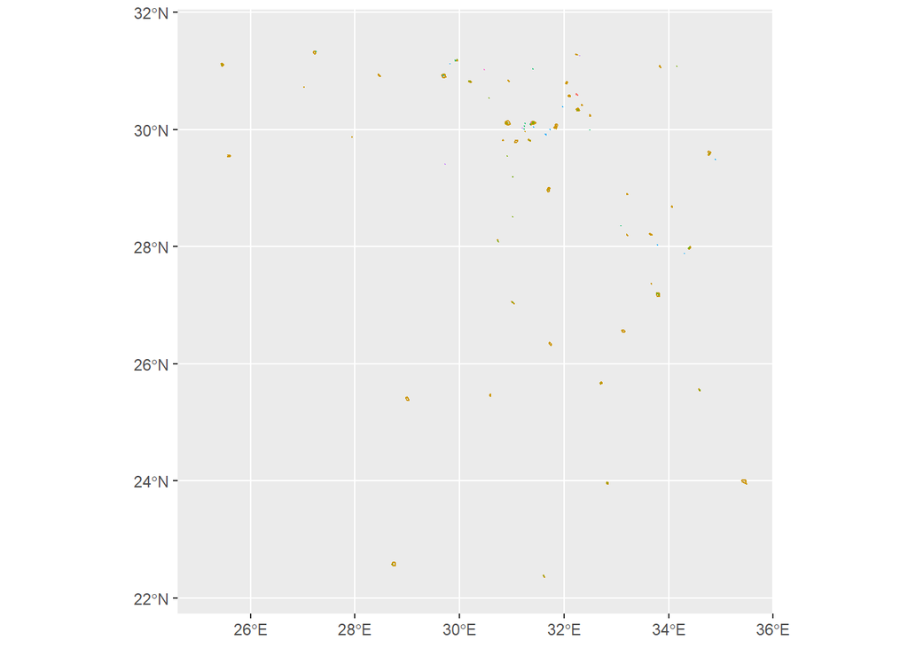

## 11. gis_osm_buildings_a_free_1

Building boundaries. Some buildings has names; I found places such as تلفزيون وراديو ماسبيرو, مستشفى العجوزة.  
*This layer is very sparse and lacks most of the buildings.*

Total number of features: 106095

Counts Table

| Class | Count | Proportion |
| --- | --- | --- |
| building | 106,095 | 100% |

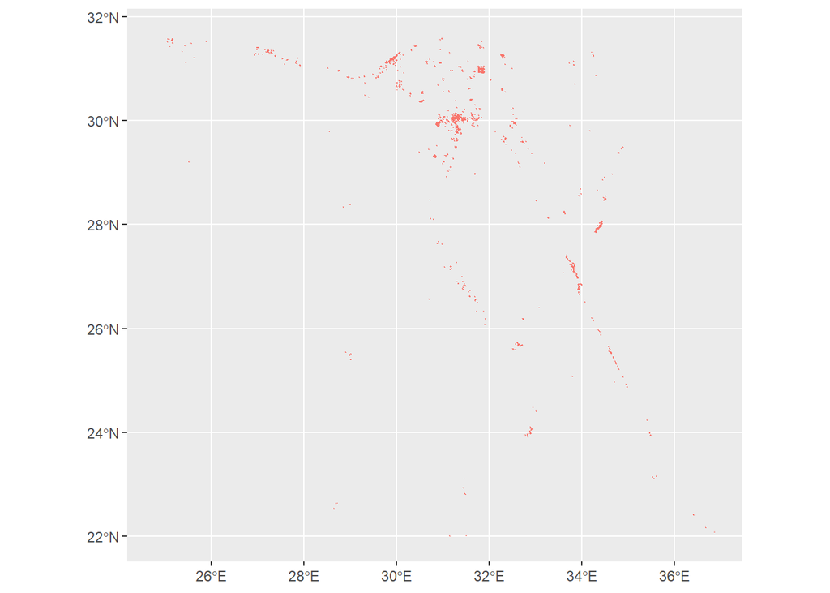

## 12. gis_osm_places_free_1

**Places**. It contains villages and others.

Total number of features: 8272

Counts Table

| Class | Count | Proportion |
| --- | --- | --- |
| village | 3,764 | 45.503% |
| locality | 3,624 | 43.810% |
| island | 259 | 3.131% |
| Other | 241 | 2.913% |
| hamlet | 235 | 2.841% |
| suburb | 149 | 1.801% |

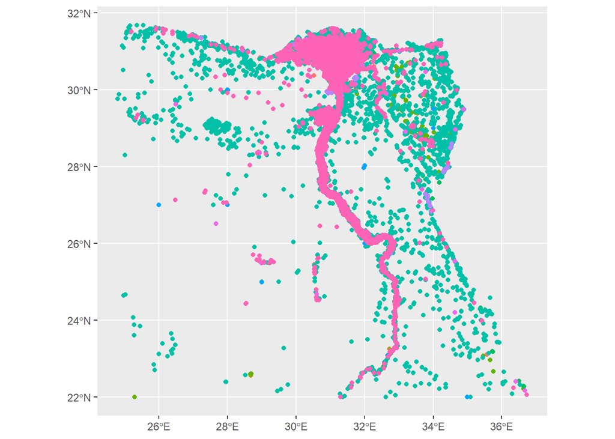

## 13. `gis_osm_places_a_free_1`

**Places** in POLYGON rather than POINT format.

Total number of features: 867

Counts Table

| Class | Count | Proportion |
| --- | --- | --- |
| village | 376 | 43.4% |
| island | 201 | 23.2% |
| locality | 99 | 11.4% |
| town | 80 | 9.2% |
| hamlet | 69 | 8.0% |
| Other | 42 | 4.8% |

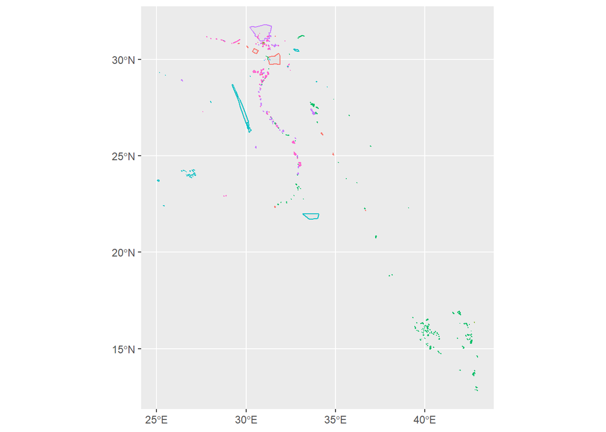

## 14. `gis_osm_natural_free_1`

**Natural** landmarks, like trees or springs.

Total number of features: 7229

Counts Table

| Class | Count | Proportion |
| --- | --- | --- |
| tree | 4,827 | 66.77% |
| peak | 1,592 | 22.02% |
| spring | 674 | 9.32% |
| cave_entrance | 78 | 1.08% |
| cliff | 52 | 0.72% |
| Other | 6 | 0.08% |

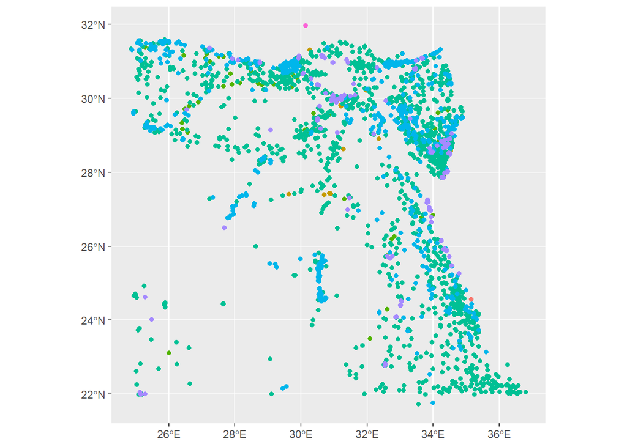

## 15. `gis_osm_natural_a_free_1`

**Natural** landmarks in POLYGON rather than POINT format.

Total number of features: 639

Counts Table

| Class | Count | Proportion |
| --- | --- | --- |
| beach | 422 | 66.04% |
| cliff | 183 | 28.64% |
| spring | 27 | 4.23% |
| peak | 3 | 0.47% |
| tree | 3 | 0.47% |
| cave_entrance | 1 | 0.16% |

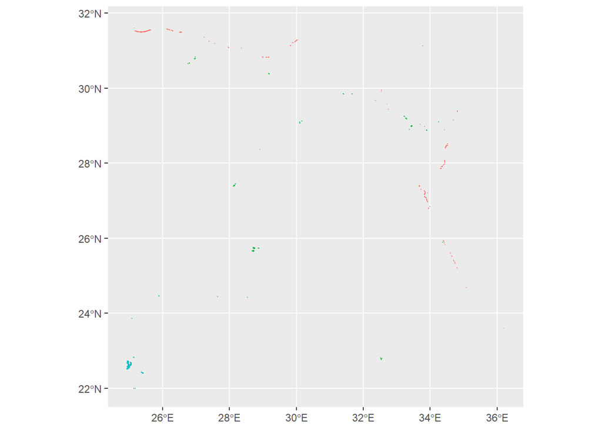

## 16. `gis_osm_water_a_free_1`

**Water** features, it includes the River Nile, lakes, … etc.

Total number of features: 2544

Counts Table

| Class | Count | Proportion |
| --- | --- | --- |
| water | 1,632 | 64.2% |
| reservoir | 514 | 20.2% |
| wetland | 274 | 10.8% |
| riverbank | 118 | 4.6% |
| dock | 6 | 0.2% |

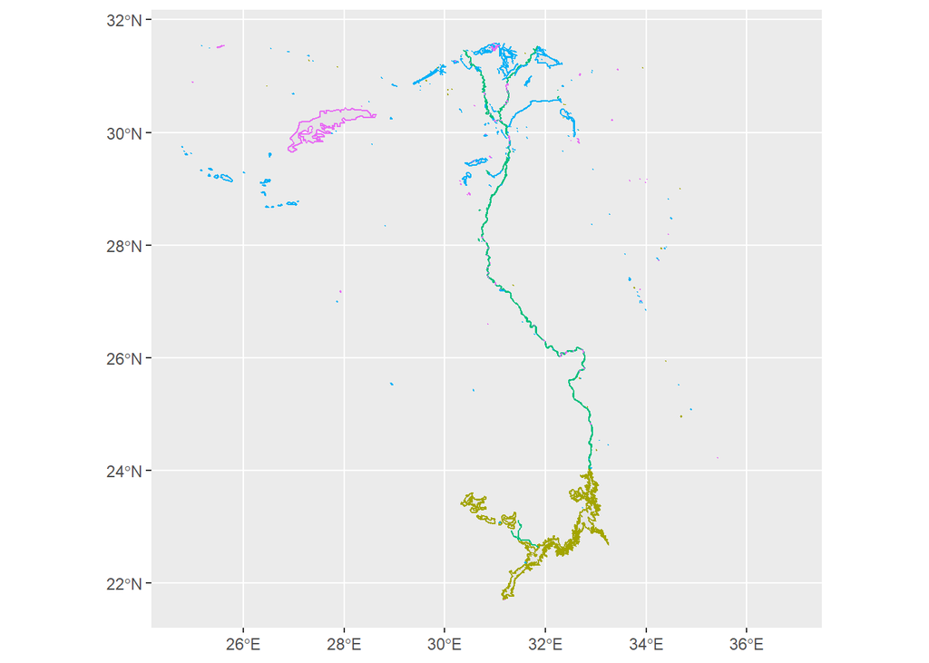